```python
import pandas as pd
import numpy as np
from statsmodels.tsa.seasonal import seasonal_decompose
import matplotlib.pyplot as plt
from matplotlib.font_manager import FontProperties
import seaborn as sns
pd.set_option('display.max_columns', 500)

plt.rcParams['axes.unicode_minus']=False
myfont=FontProperties(fname=r'/Users/suchengen/Desktop/msjh.ttf',size=14)
sns.set(font=myfont.get_family())
sns.set_style("whitegrid",{"font.sans-serif":['Microsoft JhengHei']})
```

# Data Cleaning

```python
data = pd.read_csv('不動產買賣.csv')
data = data[data['主要用途'] == '住家用']
data.reset_index(drop = True, inplace = True)
data['總價元(log)'] = np.log(data['總價元'])
data.reset_index(inplace = True, drop = True)
data['year'] = data['交易年月日'].str[:4].astype(int)
data.drop(data[data['year'] < 2013].index, axis = 0, inplace = True)
data.index = pd.to_datetime(data['交易年月日'])
# data.dropna(axis = 1, inplace = True)
data
```

| 交易年月日 | 鄉鎮市區 | 交易標的 | 土地位置建物門牌 | 土地移轉總面積平方公尺 | 都市土地使用分區 | 非都市土地使用分區 | 非都市土地使用編定 | 交易年月日 | 交易筆棟數 | 移轉層次 | 總樓層數 | 建物型態 | 主要用途 | 主要建材 | 建築完成年月 | 建物移轉總面積平方公尺 | 建物現況格局-房 | 建物現況格局-廳 | 建物現況格局-衛 | 建物現況格局-隔間 | 有無管理組織 | 總價元 | 單價元平方公尺 | 車位類別 | 車位移轉總面積(平方公尺) | 車位總價元 | 備註 | 編號 | 主建物面積 | … |
| --- | --- | --- | --- | --- | --- | --- | --- | --- | --- | --- | --- | --- | --- | --- | --- | --- | --- | --- | --- | --- | --- | --- | --- | --- | --- | --- | --- | --- | --- | --- |
| 2013-01-01 | 內湖區 | 房地(土地+建物)+車位 | 台北市內湖區民權東路六段２９６巷２６號７樓之３ | 20.38 | 住 | NaN | NaN | 2013-01-01 | 土地1建物2車位1 | 七層，電梯樓梯間 | 十六層 | 住宅大樓(11層含以上有電梯) | 住家用 | 鋼筋混凝土造 | 850628 | 126.24 | 2 | 2 | 1 | 有 | 有 | 18000000 | 142574.0 | 坡道平面 | 0.00 | 0 | 含增建或未登記建物。 | RPTNMLNLKHIFFCA37DA | 70.91 | … |
| 2013-01-01 | 士林區 | 房地(土地+建物)+車位 | 台北市士林區中山北路六段２１２之２號十樓 | 39.05 | 住 | NaN | NaN | 2013-01-01 | 土地1建物1車位2 | 十層 | 十四層 | 住宅大樓(11層含以上有電梯) | 住家用 | 鋼骨鋼筋混凝土造 | 930518 | 230.81 | 3 | 2 | 2 | 有 | 有 | 53500000 | 231792.0 | 坡道平面 | 0.00 | 0 | NaN | RPSOMLQJKHIFFEA57CA | 101.63 | … |
| 2013-01-01 | 北投區 | 房地(土地+建物) | 台北市北投區泉源路２８號六樓之２ | 6.97 | 住 | NaN | NaN | 2013-01-01 | 土地2建物1車位0 | 六層 | 七層 | 華廈(10層含以下有電梯) | 住家用 | 鋼筋混凝土造 | 700424 | 34.46 | 1 | 0 | 1 | 有 | 有 | 4050000 | 117528.0 | NaN | 0.00 | 0 | 陽台外推。 | RPRQMLSKJHIFFEA87CA | 24.82 | … |
| 2013-01-01 | 中山區 | 房地(土地+建物) | 台北市中山區南京東路二段１０８號十六樓之１７ | 2.94 | 其他 | NaN | NaN | 2013-01-01 | 土地3建物1車位0 | 十六層 | 十八層 | 套房(1房1廳1衛) | 住家用 | 見其他登記事項 | 990917 | 46.14 | 0 | 0 | 0 | 無 | 有 | 12850000 | 278500.0 | NaN | 0.00 | 0 | NaN | RPROMLQLKHIFFCA47CA | 24.83 | … |
| 2013-01-01 | 大同區 | 房地(土地+建物)+車位 | 台北市大同區承德路3段191巷6號5樓之1 | 22.39 | 商 | NaN | NaN | 2013-01-01 | 土地2建物1車位1 | 五層 | 七層 | 華廈(10層含以下有電梯) | 住家用 | 鋼筋混凝土造 | 1.0106e+06 | 109.35 | 2 | 2 | 2 | 有 | 有 | 21000000 | 192044.0 | 坡道機械 | 0.00 | 1500000 | NaN | RPTNMLLJMHIFFBA96CA | 57.39 | … |
| ... | ... | ... | ... | ... | ... | ... | ... | ... | ... | ... | ... | ... | ... | ... | ... | ... | ... | ... | ... | ... | ... | ... | ... | ... | ... | ... | ... | ... | ... | … |
| 2021-11-25 | 南港區 | 房地(土地+建物)+車位 | 臺北市南港區經貿二路２３５巷３６號八樓 | 21.28 | 都市：其他:住宅區(供商務住宅使用)。 | NaN | NaN | 2021-11-25 | 土地1建物1車位1 | 八層 | 十層 | 華廈(10層含以下有電梯) | 住家用 | 鋼筋混凝土造 | 1.031e+06 | 125.90 | 2 | 1 | 1 | 有 | 有 | 27220000 | 216203.0 | 坡道機械 | 12.50 | 0 | NaN | RPWRMLNJKIGGFDA97DA | 67.41 | … |
| 2021-11-25 | 松山區 | 房地(土地+建物)+車位 | 臺北市松山區市民大道四段３９之１號十八樓 | 52.38 | 都市：其他:第三種住宅區。 | NaN | NaN | 2021-11-25 | 土地2建物1車位3 | 十八層 | 二十三層 | 住宅大樓(11層含以上有電梯) | 住家用 | 鋼骨造 | 1.0901e+06 | 403.58 | 0 | 0 | 0 | 無 | 有 | 181680000 | 605108.0 | 坡道平面 | 121.68 | 11100000 | NaN | RPRPMLNJKIGGFDA27DA | 150.81 | … |
| 2021-11-26 | 中山區 | 房地(土地+建物) | 臺北市中山區吉林路２９８號 | 15.61 | 都市：其他:第貳種商業區(依都市計畫說明書圖規定辦理，始得作第貳種商業區使用)(原屬第參種住... | NaN | NaN | 2021-11-26 | 土地1建物1車位0 | 一層，騎樓 | 六層 | 華廈(10層含以下有電梯) | 住家用 | 鋼筋混凝土造 | 630117 | 67.62 | 0 | 0 | 0 | 無 | 有 | 6600000 | 97590.0 | NaN | 0.00 | 0 | 親友、員工、共有人或其他特殊關係間之交易； | RPTOMLQJKIGGFCA67EA | 57.52 | … |
| 2021-11-26 | 士林區 | 房地(土地+建物) | 臺北市士林區忠誠路一段１６巷２３之１號 | 5.74 | 都市：其他:第三種住宅區。 | NaN | NaN | 2021-11-26 | 土地2建物1車位0 | 一層 | 五層 | 華廈(10層含以下有電梯) | 住家用 | 鋼筋混凝土造 | 840921 | 22.35 | 2 | 1 | 1 | 有 | 有 | 5500000 | 246085.0 | NaN | 0.00 | 0 | NaN | RPSNMLSJKIGGFEA87EA | 11.19 | … |
| 2021-11-27 | 信義區 | 房地(土地+建物) | 臺北市信義區信義路五段１５０巷４１６號三樓 | 22.00 | 都市：其他:第三種住宅區。 | NaN | NaN | 2021-11-27 | 土地1建物1車位0 | 三層 | 五層 | 公寓(5樓含以下無電梯) | 住家用 | 鋼筋混凝土造 | 701204 | 77.40 | 4 | 0 | 4 | 有 | 無 | 15600000 | 201550.0 | NaN | 0.00 | 0 | NaN | RPVOMLSJKIGGFDA08DA | 67.19 | … |

127435 rows × 35 columns

```python
def convert_f(x):
    if x > 0:
        return 1
    else:
        return 0
data['建物現況格局-隔間'] = data['建物現況格局-隔間'].replace('有', 1).replace('無', 0)
data['有無管理組織'] = data['有無管理組織'].replace('有', 1).replace('無', 0)
data['陽台面積'] = data['陽台面積'].apply(convert_f)
data
```

| 交易年月日 | 鄉鎮市區 | 交易標的 | 土地位置建物門牌 | 土地移轉總面積平方公尺 | 都市土地使用分區 | 非都市土地使用分區 | 非都市土地使用編定 | 交易年月日 | 交易筆棟數 | 移轉層次 | 總樓層數 | 建物型態 | 主要用途 | 主要建材 | 建築完成年月 | 建物移轉總面積平方公尺 | 建物現況格局-房 | 建物現況格局-廳 | 建物現況格局-衛 | 建物現況格局-隔間 | 有無管理組織 | 總價元 | 單價元平方公尺 | 車位類別 | 車位移轉總面積(平方公尺) | 車位總價元 | 備註 | 編號 | 主建物面積 | … |
| --- | --- | --- | --- | --- | --- | --- | --- | --- | --- | --- | --- | --- | --- | --- | --- | --- | --- | --- | --- | --- | --- | --- | --- | --- | --- | --- | --- | --- | --- | --- |
| 2013-01-01 | 內湖區 | 房地(土地+建物)+車位 | 台北市內湖區民權東路六段２９６巷２６號７樓之３ | 20.38 | 住 | NaN | NaN | 2013-01-01 | 土地1建物2車位1 | 七層，電梯樓梯間 | 十六層 | 住宅大樓(11層含以上有電梯) | 住家用 | 鋼筋混凝土造 | 850628 | 126.24 | 2 | 2 | 1 | 1 | 1 | 18000000 | 142574.0 | 坡道平面 | 0.00 | 0 | 含增建或未登記建物。 | RPTNMLNLKHIFFCA37DA | 70.91 | … |
| 2013-01-01 | 士林區 | 房地(土地+建物)+車位 | 台北市士林區中山北路六段２１２之２號十樓 | 39.05 | 住 | NaN | NaN | 2013-01-01 | 土地1建物1車位2 | 十層 | 十四層 | 住宅大樓(11層含以上有電梯) | 住家用 | 鋼骨鋼筋混凝土造 | 930518 | 230.81 | 3 | 2 | 2 | 1 | 1 | 53500000 | 231792.0 | 坡道平面 | 0.00 | 0 | NaN | RPSOMLQJKHIFFEA57CA | 101.63 | … |
| 2013-01-01 | 北投區 | 房地(土地+建物) | 台北市北投區泉源路２８號六樓之２ | 6.97 | 住 | NaN | NaN | 2013-01-01 | 土地2建物1車位0 | 六層 | 七層 | 華廈(10層含以下有電梯) | 住家用 | 鋼筋混凝土造 | 700424 | 34.46 | 1 | 0 | 1 | 1 | 1 | 4050000 | 117528.0 | NaN | 0.00 | 0 | 陽台外推。 | RPRQMLSKJHIFFEA87CA | 24.82 | … |
| 2013-01-01 | 中山區 | 房地(土地+建物) | 台北市中山區南京東路二段１０８號十六樓之１７ | 2.94 | 其他 | NaN | NaN | 2013-01-01 | 土地3建物1車位0 | 十六層 | 十八層 | 套房(1房1廳1衛) | 住家用 | 見其他登記事項 | 990917 | 46.14 | 0 | 0 | 0 | 0 | 1 | 12850000 | 278500.0 | NaN | 0.00 | 0 | NaN | RPROMLQLKHIFFCA47CA | 24.83 | … |
| 2013-01-01 | 大同區 | 房地(土地+建物)+車位 | 台北市大同區承德路3段191巷6號5樓之1 | 22.39 | 商 | NaN | NaN | 2013-01-01 | 土地2建物1車位1 | 五層 | 七層 | 華廈(10層含以下有電梯) | 住家用 | 鋼筋混凝土造 | 1.0106e+06 | 109.35 | 2 | 2 | 2 | 1 | 1 | 21000000 | 192044.0 | 坡道機械 | 0.00 | 1500000 | NaN | RPTNMLLJMHIFFBA96CA | 57.39 | … |
| ... | ... | ... | ... | ... | ... | ... | ... | ... | ... | ... | ... | ... | ... | ... | ... | ... | ... | ... | ... | ... | ... | ... | ... | ... | ... | ... | ... | ... | ... | … |
| 2021-11-25 | 南港區 | 房地(土地+建物)+車位 | 臺北市南港區經貿二路２３５巷３６號八樓 | 21.28 | 都市：其他:住宅區(供商務住宅使用)。 | NaN | NaN | 2021-11-25 | 土地1建物1車位1 | 八層 | 十層 | 華廈(10層含以下有電梯) | 住家用 | 鋼筋混凝土造 | 1.031e+06 | 125.90 | 2 | 1 | 1 | 1 | 1 | 27220000 | 216203.0 | 坡道機械 | 12.50 | 0 | NaN | RPWRMLNJKIGGFDA97DA | 67.41 | … |
| 2021-11-25 | 松山區 | 房地(土地+建物)+車位 | 臺北市松山區市民大道四段３９之１號十八樓 | 52.38 | 都市：其他:第三種住宅區。 | NaN | NaN | 2021-11-25 | 土地2建物1車位3 | 十八層 | 二十三層 | 住宅大樓(11層含以上有電梯) | 住家用 | 鋼骨造 | 1.0901e+06 | 403.58 | 0 | 0 | 0 | 0 | 1 | 181680000 | 605108.0 | 坡道平面 | 121.68 | 11100000 | NaN | RPRPMLNJKIGGFDA27DA | 150.81 | … |
| 2021-11-26 | 中山區 | 房地(土地+建物) | 臺北市中山區吉林路２９８號 | 15.61 | 都市：其他:第貳種商業區(依都市計畫說明書圖規定辦理，始得作第貳種商業區使用)(原屬第參種住... | NaN | NaN | 2021-11-26 | 土地1建物1車位0 | 一層，騎樓 | 六層 | 華廈(10層含以下有電梯) | 住家用 | 鋼筋混凝土造 | 630117 | 67.62 | 0 | 0 | 0 | 0 | 1 | 6600000 | 97590.0 | NaN | 0.00 | 0 | 親友、員工、共有人或其他特殊關係間之交易； | RPTOMLQJKIGGFCA67EA | 57.52 | … |
| 2021-11-26 | 士林區 | 房地(土地+建物) | 臺北市士林區忠誠路一段１６巷２３之１號 | 5.74 | 都市：其他:第三種住宅區。 | NaN | NaN | 2021-11-26 | 土地2建物1車位0 | 一層 | 五層 | 華廈(10層含以下有電梯) | 住家用 | 鋼筋混凝土造 | 840921 | 22.35 | 2 | 1 | 1 | 1 | 1 | 5500000 | 246085.0 | NaN | 0.00 | 0 | NaN | RPSNMLSJKIGGFEA87EA | 11.19 | … |
| 2021-11-27 | 信義區 | 房地(土地+建物) | 臺北市信義區信義路五段１５０巷４１６號三樓 | 22.00 | 都市：其他:第三種住宅區。 | NaN | NaN | 2021-11-27 | 土地1建物1車位0 | 三層 | 五層 | 公寓(5樓含以下無電梯) | 住家用 | 鋼筋混凝土造 | 701204 | 77.40 | 4 | 0 | 4 | 1 | 0 | 15600000 | 201550.0 | NaN | 0.00 | 0 | NaN | RPVOMLSJKIGGFDA08DA | 67.19 | … |

127435 rows × 35 columns

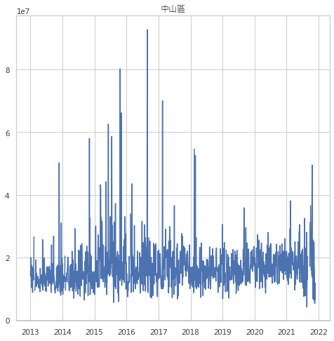

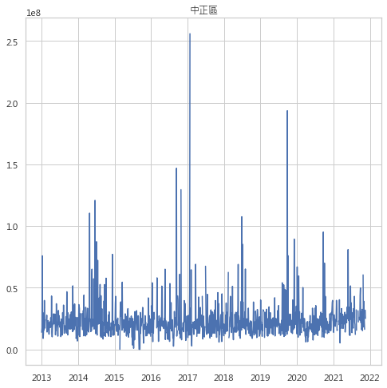

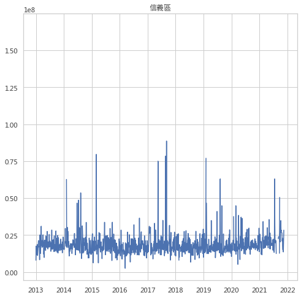

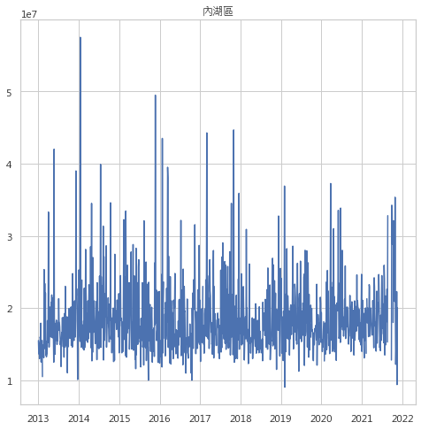

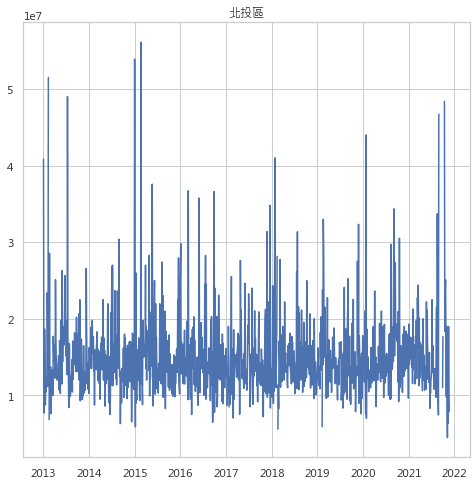

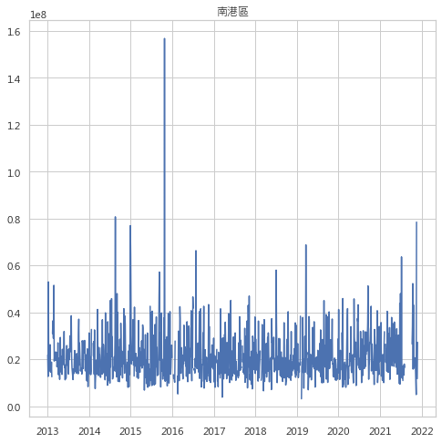

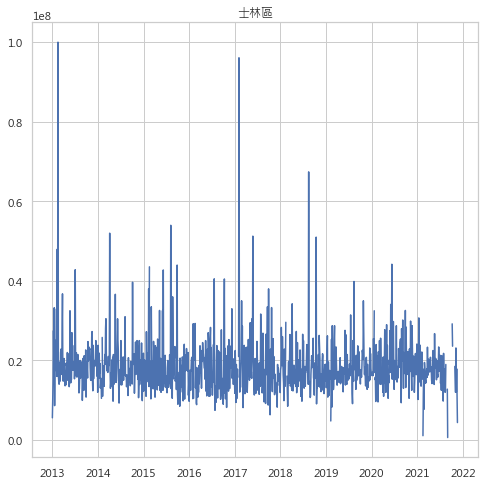

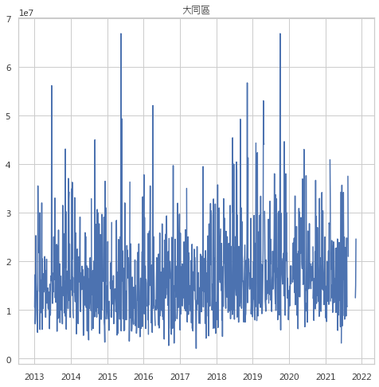

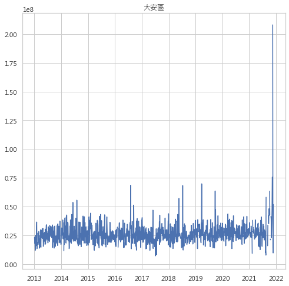

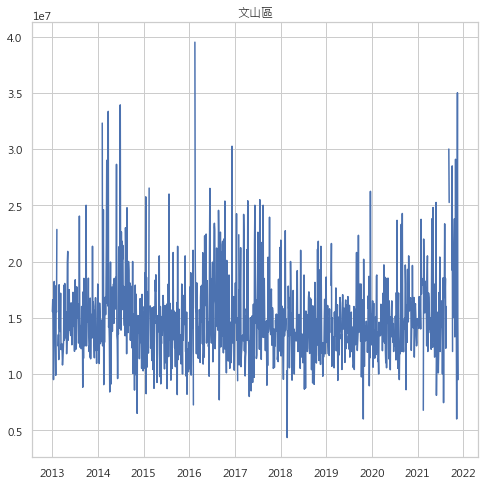

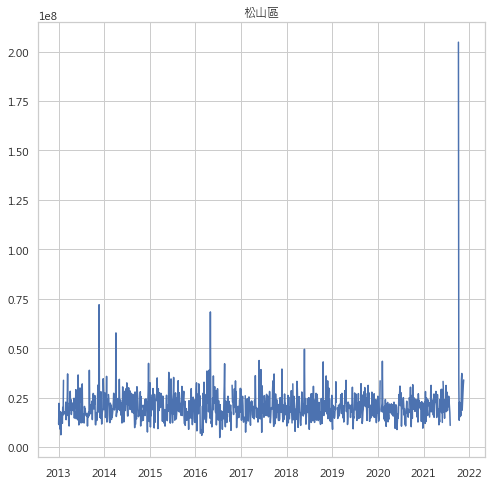

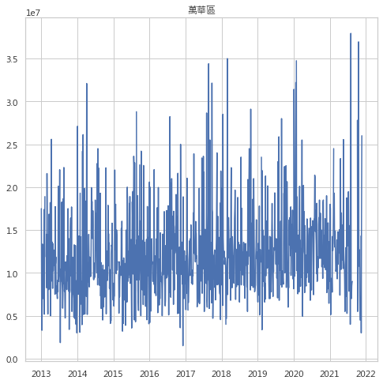

```python
sector = np.unique(data['鄉鎮市區'].tolist())
group = data.groupby('鄉鎮市區')
for i in sector:
    plt.figure(figsize = (8,8))
    # 照行政區分群
    g = group.get_group(i)
    # 將資料以每月整合並取平均值
    time_g = g.groupby(pd.Grouper(freq='3d')).median()
    # 用插值法補齊缺失值：前後資料平均
    time_g['總價元(log)'] = time_g['總價元(log)'].interpolate(method='linear')
    plt.plot(time_g['總價元'])
    plt.title(i)
    plt.show()
```

```python
s1 = (group.get_group('中山區')).groupby(pd.Grouper(freq = '3d')).median()
s1['總價元(log)'] = s1['總價元(log)'].interpolate(method='linear')
s1['總價元'] = s1['總價元'].interpolate(method='linear')
s1
```

| 交易年月日 | 土地移轉總面積平方公尺 | 建物移轉總面積平方公尺 | 建物現況格局-房 | 建物現況格局-廳 | 建物現況格局-衛 | 建物現況格局-隔間 | 有無管理組織 | 總價元 | 車位移轉總面積(平方公尺) | 車位總價元 | 主建物面積 | 附屬建物面積 | 陽台面積 | 總價元(log) | year |
| --- | --- | --- | --- | --- | --- | --- | --- | --- | --- | --- | --- | --- | --- | --- | --- |
| 2013-01-01 | 21.600 | 73.210 | 2.0 | 1.0 | 1.0 | 1.0 | 1.0 | 13950000.0 | 0.00 | 0.0 | 40.260 | 1.380 | 1.0 | 16.450990 | 2013.0 |
| 2013-01-04 | 19.805 | 121.045 | 2.0 | 1.0 | 1.0 | 1.0 | 1.0 | 19965000.0 | 6.29 | 210000.0 | 57.925 | 3.040 | 1.0 | 16.809457 | 2013.0 |
| 2013-01-07 | 20.380 | 83.880 | 1.0 | 1.0 | 1.0 | 1.0 | 1.0 | 14075000.0 | 0.00 | 0.0 | 66.670 | 0.275 | 1.0 | 16.459455 | 2013.0 |
| 2013-01-10 | 11.540 | 105.770 | 1.0 | 1.0 | 1.0 | 1.0 | 1.0 | 14000000.0 | 0.00 | 0.0 | 49.420 | 0.700 | 1.0 | 16.454568 | 2013.0 |
| 2013-01-13 | 7.250 | 58.295 | 1.0 | 1.0 | 1.0 | 1.0 | 1.0 | 10400000.0 | 0.00 | 0.0 | 37.835 | 0.640 | 1.0 | 16.156576 | 2013.0 |
| ... | ... | ... | ... | ... | ... | ... | ... | ... | ... | ... | ... | ... | ... | ... | ... |
| 2021-11-12 | 19.310 | 75.700 | 1.5 | 1.0 | 1.0 | 1.0 | 0.5 | 17300000.0 | 0.00 | 0.0 | 60.060 | 7.070 | 0.0 | 16.662444 | 2021.0 |
| 2021-11-15 | 14.320 | 71.800 | 1.0 | 1.0 | 1.0 | 1.0 | 1.0 | 15600000.0 | 11.38 | 0.0 | 31.360 | 7.890 | 0.0 | 16.562781 | 2021.0 |
| 2021-11-18 | 3.280 | 31.010 | 1.0 | 1.0 | 1.0 | 1.0 | 1.0 | 5280000.0 | 0.00 | 0.0 | 20.770 | 2.910 | 0.0 | 15.479437 | 2021.0 |
| 2021-11-21 | 6.240 | 41.580 | 3.0 | 1.0 | 1.0 | 1.0 | 1.0 | 11800000.0 | 0.00 | 0.0 | 24.400 | 2.950 | 0.0 | 16.283610 | 2021.0 |
| 2021-11-24 | 15.610 | 67.620 | 0.0 | 0.0 | 0.0 | 0.0 | 1.0 | 6600000.0 | 0.00 | 0.0 | 57.520 | 3.960 | 0.0 | 15.702580 | 2021.0 |

1084 rows × 15 columns

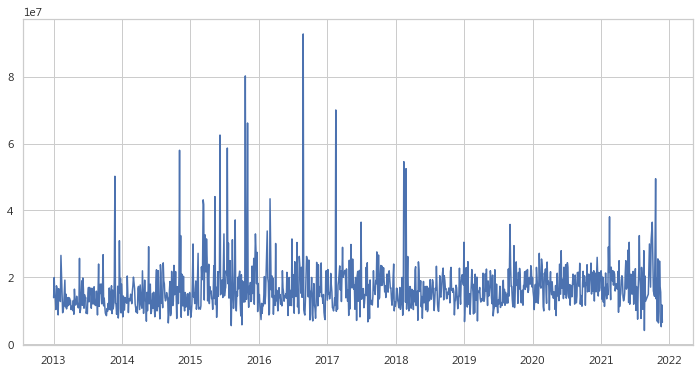

```python
plt.figure(figsize = (12, 6))
plt.plot(s1['總價元'])
```

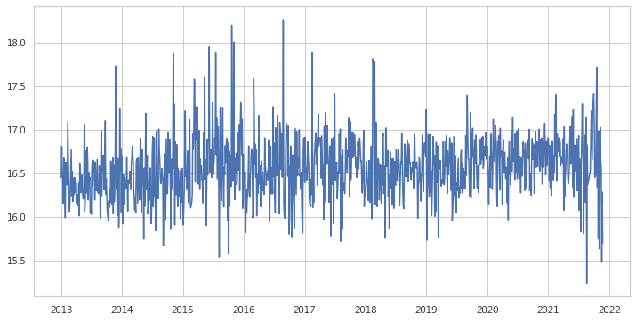

```python
plt.figure(figsize = (12, 6))
plt.plot(s1['總價元(log)'])
```

# 自相關與偏自相關函數

自相關是序列和自己滯後量的簡單相關。如果序列顯著自相關，均值和序列之前的值（滯後量）可能對預測當前值有幫助。

偏自相關也會傳遞相似的信息但是它傳遞的是序列和它滯後量的純粹相關，排除了其他中間滯後量對相關的貢獻。

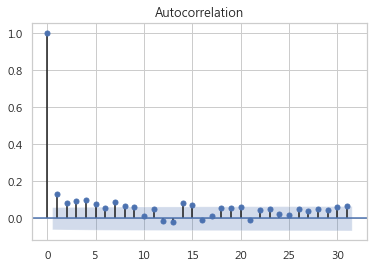

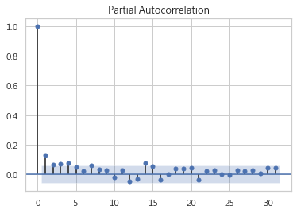

```python
from statsmodels.graphics.tsaplots import plot_acf , plot_pacf
plot_acf(s1['總價元(log)'].values)
plot_pacf(s1['總價元(log)'].values)
plt.show()
```

# ADF Test & KPSS Test

ADF Test：原假設序列為不平穩，若統計量小於 1%、5%、10%，則有(99%，95，90%）的機率來拒絕原假設，而序列則平穩，反之則不平穩。

1：兩個測試都得出序列不穩定->不平穩

2：兩個測試都平穩->序列平穩

3：KPSS=平穩的，ADF=不平穩->趨勢平穩，刪除趨勢使序列嚴格平穩情況

4：KPSS=非平穩且ADF平穩->差分平穩，使用差分使序列平穩

```python
from statsmodels.tsa.stattools import adfuller, kpss
log_price = s1['總價元(log)']
dftest = kpss(log_price, 'ct')
print("KPSS Test statistic = {:.3f}".format(dftest[0]))
print("P-value = {:.3f}".format(dftest[1]))
print("Critical values :")
for k, v in dftest[3].items():
    print("\t{}: {}".format(k, v))

result = adfuller(log_price, autolag='AIC')
print(f'ADF Statistic: {result[0]}')
print(f'p-value: {result[1]}')
for key, value in result[4].items():
    print('Critial Values:')
    print(f' {key}, {value}')
```

```
KPSS Test statistic = 0.167
P-value = 0.032
Critical values :
	10%: 0.119
	5%: 0.146
	2.5%: 0.176
	1%: 0.216
ADF Statistic: -9.478635497368161
p-value: 3.9271330989286827e-16
Critial Values:
 1%, -3.436436308605049
Critial Values:
 5%, -2.8642273405849363
Critial Values:
 10%, -2.568200833956216
```

```python
from statsmodels.tsa.stattools import adfuller, kpss
diff_log_price = s1['總價元(log)'].diff(1)
diff_log_price.dropna(inplace = True)
dftest = kpss(diff_log_price, 'ct')
print("KPSS Test statistic = {:.3f}".format(dftest[0]))
print("P-value = {:.3f}".format(dftest[1]))
print("Critical values :")
for k, v in dftest[3].items():
    print("\t{}: {}".format(k, v))

result = adfuller(diff_log_price, autolag='AIC')
print(f'ADF Statistic: {result[0]}')
print(f'p-value: {result[1]}')
for key, value in result[4].items():
    print('Critial Values:')
    print(f' {key}, {value}')
```

```
KPSS Test statistic = 0.020
P-value = 0.100
Critical values :
	10%: 0.119
	5%: 0.146
	2.5%: 0.176
	1%: 0.216
ADF Statistic: -12.612326729226561
p-value: 1.6449726182312084e-23
Critial Values:
 1%, -3.436510851955201
Critial Values:
 5%, -2.864260220574562
Critial Values:
 10%, -2.5682183458999943
```

# 白噪音檢測

如平穩序列，白噪音也不是時間的函數，它的均值和方差並不隨時間變化。但是它與平穩序列的差異在於，白噪音完全隨機，均值為0。 從數學上來看，均值為0的完全隨機的數字序列是白噪音。

p < 0.05，拒絕原假設，序列為平穩且非白噪音

```python
from statsmodels.stats.diagnostic import acorr_ljungbox
print('白噪聲檢測結果 p值:',acorr_ljungbox(log_price,lags=1)[1][0])
```

```
白噪聲檢測結果 p值: 1.2258087221077352e-05
```

# 時間序列分解

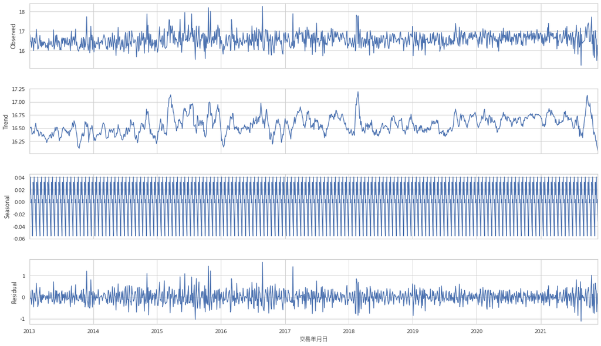

```python
decompose_result = seasonal_decompose(log_price, model='additive', extrapolate_trend='freq')
# fig = plt.figure(figsize = (20, 12))
fig = decompose_result.plot()
fig.set_size_inches(20,12)
```

# 殘差檢測與獨立殘差檢測

確認分解後的殘差是否為白噪音序列，是白噪音才能接續預測

獨立殘差在2附近說明滿足殘差獨立性

```python
from statsmodels.stats.stattools import durbin_watson
print('白噪聲檢測結果 p值: %.6f' %(acorr_ljungbox(decompose_result.resid,lags=1)[1][0]))
print('獨立殘差檢測 ：', durbin_watson(decompose_result.resid))
```

```
白噪聲檢測結果 p值: 0.000000
獨立殘差檢測 ： 2.3170000395576857
```

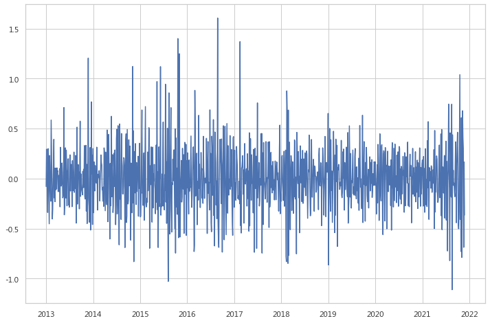

```python
detrend = log_price - decompose_result.trend
plt.figure(figsize = (12, 8))
plt.plot(detrend)
```

```python
from statsmodels.tsa.stattools import adfuller, kpss
log_price = s1['總價元(log)']
dftest = kpss(detrend, 'ct')
print("KPSS Test statistic = {:.3f}".format(dftest[0]))
print("P-value = {:.3f}".format(dftest[1]))
print("Critical values :")
for k, v in dftest[3].items():
    print("\t{}: {}".format(k, v))

result = adfuller(detrend, autolag='AIC')
print(f'ADF Statistic: {result[0]}')
print(f'p-value: {result[1]}')
for key, value in result[4].items():
    print('Critial Values:')
    print(f' {key}, {value}')
```

```
KPSS Test statistic = 0.011
P-value = 0.100
Critical values :
	10%: 0.119
	5%: 0.146
	2.5%: 0.176
	1%: 0.216
ADF Statistic: -14.36578592211471
p-value: 9.677863012078666e-27
Critial Values:
 1%, -3.4365224825380714
Critial Values:
 5%, -2.86426535058257
Critial Values:
 10%, -2.568221078163292
```

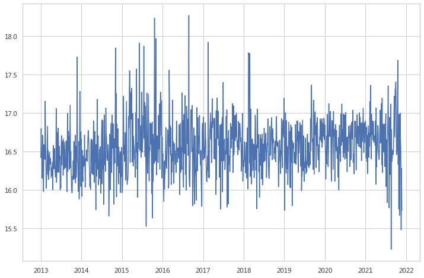

```python
deseason = s1['總價元(log)'] - decompose_result.seasonal
plt.figure(figsize = (12, 8))
plt.plot(deseason)
```

# 單變量時間序列分析

# ARIMA

ARIMA（p，d，q）中，AR是"自回歸"，p為自回歸項數；MA為"滑動平均"，q為滑動平均項數，d為使之成為平穩序列所做的差分次數（階數）。

```python
log_price = s1['總價元(log)']
log_price
```

```
交易年月日
2013-01-01    16.450990
2013-01-04    16.809457
2013-01-07    16.459455
2013-01-10    16.454568
2013-01-13    16.156576
                ...
2021-11-12    16.662444
2021-11-15    16.562781
2021-11-18    15.479437
2021-11-21    16.283610
2021-11-24    15.702580
Freq: 3D, Name: 總價元(log), Length: 1084, dtype: float64
```

```
                             ARIMA Model Results
==============================================================================
Dep. Variable:             D.總價元(log)   No. Observations:                 1083
Model:                 ARIMA(2, 1, 0)   Log Likelihood                -516.657
Method:                       css-mle   S.D. of innovations              0.390
Date:                Mon, 17 Jan 2022   AIC                           1041.315
Time:                        13:32:20   BIC                           1061.265
Sample:                    01-04-2013   HQIC                          1048.868
                         - 11-24-2021
====================================================================================
                       coef    std err          z      P>|z|      [0.025      0.975]
------------------------------------------------------------------------------------
const               -0.0007      0.006     -0.109      0.913      -0.013       0.011
ar.L1.D.總價元(log)    -0.6249      0.029    -21.809      0.000      -0.681      -0.569
ar.L2.D.總價元(log)    -0.3323      0.029    -11.585      0.000      -0.388      -0.276
                                    Roots
=============================================================================
                  Real          Imaginary           Modulus         Frequency
-----------------------------------------------------------------------------
AR.1           -0.9404           -1.4579j            1.7348           -0.3412
AR.2           -0.9404           +1.4579j            1.7348            0.3412
-----------------------------------------------------------------------------
```

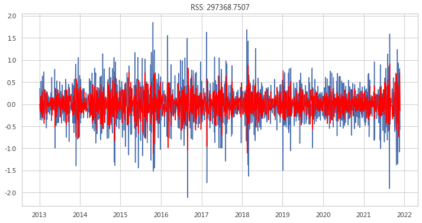

```python
from statsmodels.tsa.arima_model import ARIMA
# AR model
model = ARIMA(log_price, order=(2, 1, 0))
results_AR = model.fit(disp=-1)
plt.figure(figsize = (12, 6))
plt.plot(diff_log_price, label = 'ground truth')
plt.plot(results_AR.fittedvalues, color='red')
plt.title('RSS: %.4f'% sum((results_AR.fittedvalues - log_price[1:])**2))
print(results_AR.summary())
```

```
                             ARIMA Model Results
==============================================================================
Dep. Variable:             D.總價元(log)   No. Observations:                 1083
Model:                 ARIMA(0, 1, 2)   Log Likelihood                -396.065
Method:                       css-mle   S.D. of innovations              0.348
Date:                Mon, 17 Jan 2022   AIC                            800.129
Time:                        13:32:24   BIC                            820.079
Sample:                    01-04-2013   HQIC                           807.682
                         - 11-24-2021
====================================================================================
                       coef    std err          z      P>|z|      [0.025      0.975]
------------------------------------------------------------------------------------
const                0.0002      0.000      0.874      0.382      -0.000       0.001
ma.L1.D.總價元(log)    -0.9004      0.030    -30.215      0.000      -0.959      -0.842
ma.L2.D.總價元(log)    -0.0793      0.030     -2.642      0.008      -0.138      -0.020
                                    Roots
=============================================================================
                  Real          Imaginary           Modulus         Frequency
-----------------------------------------------------------------------------
MA.1            1.0191           +0.0000j            1.0191            0.0000
MA.2          -12.3679           +0.0000j           12.3679            0.5000
-----------------------------------------------------------------------------
```

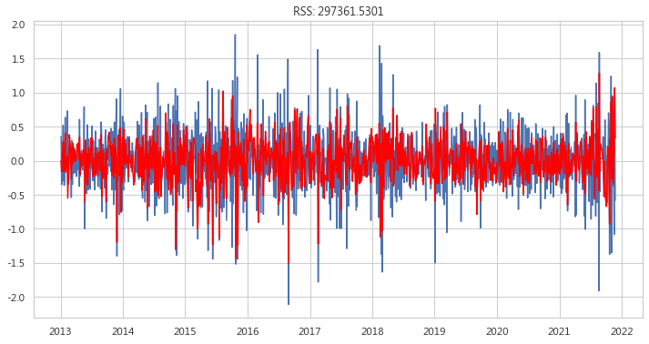

```python
# MA model
model = ARIMA(log_price, order=(0, 1, 2))
results_MR = model.fit(disp = -1)
plt.figure(figsize = (12, 6))
plt.plot(diff_log_price, label = 'ground truth')
plt.plot(results_MR.fittedvalues, color='red')
plt.title('RSS: %.4f'% sum((results_MR.fittedvalues - log_price[1:])**2))
print(results_MR.summary())
```

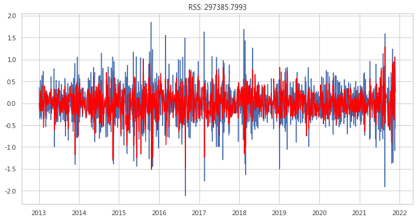

```python
# ARIMA model
model = ARIMA(log_price, order=(2, 1, 2))
results_ARIMA = model.fit(disp=-1)
plt.figure(figsize = (12, 6))
plt.plot(diff_log_price)
plt.plot(results_ARIMA.fittedvalues, color='red')
plt.title('RSS: %.4f'% sum((results_ARIMA.fittedvalues-log_price[1:])**2))
```

```python
log_price.dropna()[:-300]
```

```
交易年月日
2013-01-01    16.450990
2013-01-04    16.809457
2013-01-07    16.459455
2013-01-10    16.454568
2013-01-13    16.156576
                ...
2019-05-27    16.447399
2019-05-30    16.303532
2019-06-02    16.845458
2019-06-05    15.955577
2019-06-08    16.123071
Freq: 3D, Name: 總價元(log), Length: 784, dtype: float64
```

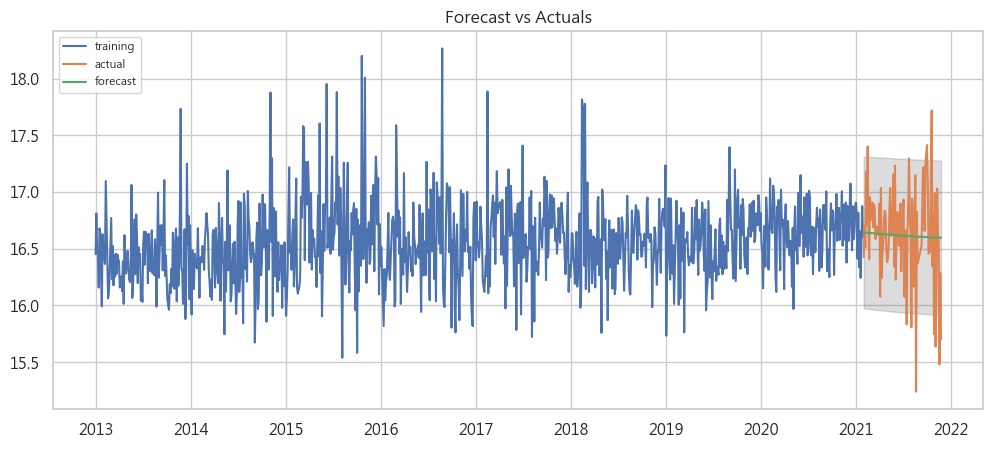

```python
train = log_price.dropna()[:-100]
test = log_price.dropna()[-100:]
model = ARIMA(train, (2, 0, 1))
results_ARIMA = model.fit()
fc, se, conf = results_ARIMA.forecast(100, alpha=0.05)
fc_series = pd.Series(fc, index=test.index)
lower_series = pd.Series(conf[:, 0], index=test.index)
upper_series = pd.Series(conf[:, 1], index=test.index)

# Plot
plt.figure(figsize=(12,5), dpi=100)
plt.plot(train, label='training')
plt.plot(test, label='actual')
plt.plot(fc_series, label='forecast')
plt.fill_between(lower_series.index, lower_series, upper_series,
                 color='k', alpha=.15)
plt.title('Forecast vs Actuals')
plt.legend(loc='upper left', fontsize=8)
plt.show()
```

# XGBregressor

```python
log_price = s1[['總價元(log)']]
log_price['target'] = log_price['總價元(log)'].shift(-1)
log_price.dropna(inplace = True)
log_price
```

| 交易年月日 | 總價元(log) | target |
| --- | --- | --- |
| 2013-01-01 | 16.450990 | 16.809457 |
| 2013-01-04 | 16.809457 | 16.459455 |
| 2013-01-07 | 16.459455 | 16.454568 |
| 2013-01-10 | 16.454568 | 16.156576 |
| 2013-01-13 | 16.156576 | 16.677711 |
| ... | ... | ... |
| 2021-11-09 | 17.029725 | 16.662444 |
| 2021-11-12 | 16.662444 | 16.562781 |
| 2021-11-15 | 16.562781 | 15.479437 |
| 2021-11-18 | 15.479437 | 16.283610 |
| 2021-11-21 | 16.283610 | 15.702580 |

1083 rows × 2 columns

```python
n = len(log_price)
train_size = int(n*0.9)
train = log_price[: train_size]
test = log_price[train_size:]
train
```

| 交易年月日 | 總價元(log) | target |
| --- | --- | --- |
| 2013-01-01 | 16.450990 | 16.809457 |
| 2013-01-04 | 16.809457 | 16.459455 |
| 2013-01-07 | 16.459455 | 16.454568 |
| 2013-01-10 | 16.454568 | 16.156576 |
| 2013-01-13 | 16.156576 | 16.677711 |
| ... | ... | ... |
| 2020-12-17 | 16.484039 | 16.872515 |
| 2020-12-20 | 16.872515 | 16.583092 |
| 2020-12-23 | 16.583092 | 16.648085 |
| 2020-12-26 | 16.648085 | 16.876099 |
| 2020-12-29 | 16.876099 | 16.906553 |

974 rows × 2 columns

```python
train = np.array(train)
test = np.array(test)
x_train, y_train = train[:, :-1], train[:, -1]
x_test, y_test = test[:, :-1], train[:, -1]
```

```python
from xgboost.sklearn import XGBRegressor
reg = XGBRegressor(n_estimators = 1000)
reg.fit(x_train, y_train)
```

```
XGBRegressor(base_score=0.5, booster='gbtree', colsample_bylevel=1,
             colsample_bynode=1, colsample_bytree=1, enable_categorical=False,
             gamma=0, gpu_id=-1, importance_type=None,
             interaction_constraints='', learning_rate=0.300000012,
             max_delta_step=0, max_depth=6, min_child_weight=1, missing=nan,
             monotone_constraints='()', n_estimators=1000, n_jobs=12,
             num_parallel_tree=1, predictor='auto', random_state=0, reg_alpha=0,
             reg_lambda=1, scale_pos_weight=1, subsample=1, tree_method='exact',
             validate_parameters=1, verbosity=None)
```

```python
def xgb_predict(train, val):
    train = np.array(train)
    x, y = train[:, :-1], train[:, -1]
    model = XGBRegressor(n_estimators = 1000)
    model.fit(x, y)

    val = np.array(val).reshape(1, -1)
    pred = model.predict(val)
    return pred[0]
```

### Walk-forward validation

不斷加入預測過的test data進入train data

```python
from sklearn.metrics import mean_squared_error

def validate(train, test):
    predictions = []

    history = [x for x in train]

    for i in range(len(test)):
        test_x, test_y = test[i, :-1], test[:, -1]

        pred = xgb_predict(history, test_x[0])
        predictions.append(pred)

        history.append(test[i])
    error = mean_squared_error(test[:, -1], predictions, squared = False)

    return error, test[:, -1], predictions
```

```python
rmse, y, pred = validate(train, test)
```

```python
print('RMSE Loss: %.5f' %(rmse))
```

```
RMSE Loss: 0.55154
```

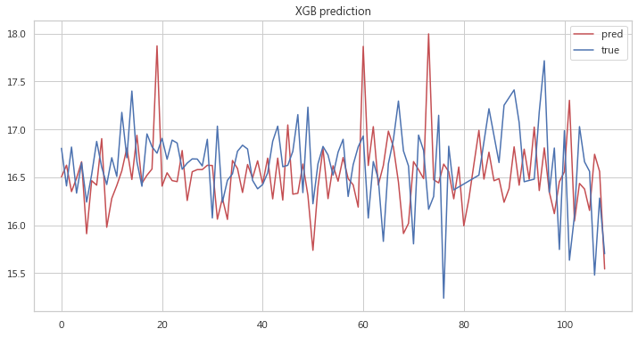

```python
plt.figure(figsize = (12, 6))
plt.plot(pred, c = 'r', label = 'pred')
plt.plot(test[:, -1], c = 'b', label = 'true')
plt.title('XGB prediction')
plt.legend(loc = 'best')
plt.show()
```

# Time-Rolling LSTM

```python
from keras.models import Sequential
from keras.layers import Dense, Dropout, Activation, Flatten, LSTM, TimeDistributed, RepeatVector
from tensorflow.keras.layers import BatchNormalization
from tensorflow.keras.optimizers import Adam
from keras.callbacks import EarlyStopping, ModelCheckpoint
import tensorflow as tf
```

```python
log_price
```

| 交易年月日 | 總價元(log) | target |
| --- | --- | --- |
| 2013-01-01 | 16.450990 | 16.809457 |
| 2013-01-04 | 16.809457 | 16.459455 |
| 2013-01-07 | 16.459455 | 16.454568 |
| 2013-01-10 | 16.454568 | 16.156576 |
| 2013-01-13 | 16.156576 | 16.677711 |
| ... | ... | ... |
| 2021-11-09 | 17.029725 | 16.662444 |
| 2021-11-12 | 16.662444 | 16.562781 |
| 2021-11-15 | 16.562781 | 15.479437 |
| 2021-11-18 | 15.479437 | 16.283610 |
| 2021-11-21 | 16.283610 | 15.702580 |

1083 rows × 2 columns

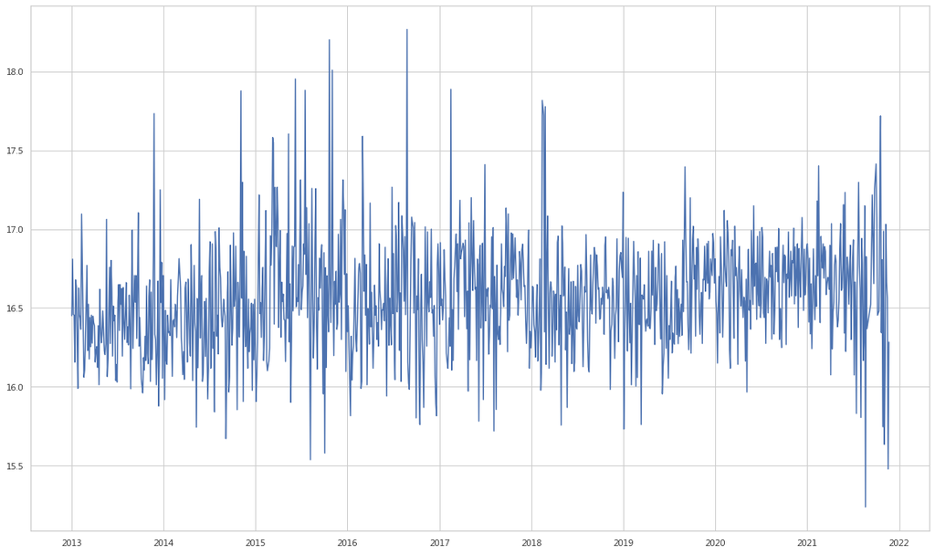

```python
plt.figure(figsize = (20, 12))
plt.plot(log_price['總價元(log)'])
```

```python
def buildTrain(t, pastDay = 7, futureDay = 7):
    X_train, Y_train = [], []
    for i in range(t.shape[0]-futureDay-pastDay):
        X_train.append(np.array(t.iloc[i:i+pastDay]))
        Y_train.append(np.array(t.iloc[i+pastDay:i+pastDay+futureDay]))
    return np.array(X_train), np.array(Y_train)

price = log_price['總價元(log)']
size = int(len(price) * 0.9)
train, test = price.iloc[:size], price.iloc[size:]
X_train, Y_train = buildTrain(train)
X_test, Y_test = buildTrain(test)
X_train = X_train[:, :, np.newaxis]
X_test = X_test[:, :, np.newaxis]
Y_train = Y_train[:,:,np.newaxis]
Y_test = Y_test[:,:,np.newaxis]
print("training examples:", len(train))
print("testing examples:", len(test))
```

```
training examples: 974
testing examples: 109
```

```python
from keras import backend as K
def root_mean_squared_error(y_true, y_pred):
        return K.sqrt(K.mean(K.square(y_pred - y_true)))
def buildManyToManyModel(shape):
    model = Sequential()
    model.add(LSTM(50, input_length=shape[1], input_dim=shape[2], return_sequences=True))
    model.add(LSTM(25, input_length=shape[1], input_dim=shape[2], return_sequences=True, dropout=0.3, recurrent_dropout=0.3))
    # output shape: (5, 1)
    model.add(TimeDistributed(Dense(1)))
    opt = Adam(learning_rate=0.003)
    model.compile(loss=root_mean_squared_error, optimizer="adam")
    model.summary()
    return model
```

```python
model = buildManyToManyModel(X_train.shape)
#     callback = EarlyStopping(monitor="loss", patience=10, verbose=1, mode="auto")
model.fit(X_train, Y_train, epochs=1000, batch_size= 256, verbose = 1)
y_pred = model.predict(X_test)
```

```
_________________________________________________________________
Layer (type)                 Output Shape              Param #
=================================================================
lstm_52 (LSTM)               (None, 7, 50)             10400
_________________________________________________________________
lstm_53 (LSTM)               (None, 7, 25)             7600
_________________________________________________________________
time_distributed_32 (TimeDis (None, 7, 1)              26
=================================================================
Total params: 18,026
Trainable params: 18,026
Non-trainable params: 0
_________________________________________________________________
```

```python
print("Test RMSE Loss:", mean_squared_error(y_pred.reshape(95,7), X_test.reshape(95,7), squared = False))
```

```
Test RMSE Loss: 0.38826709805668763
```